# The Development of Polarity Subjunctive

## 💡 Multiple Linguistic Changes

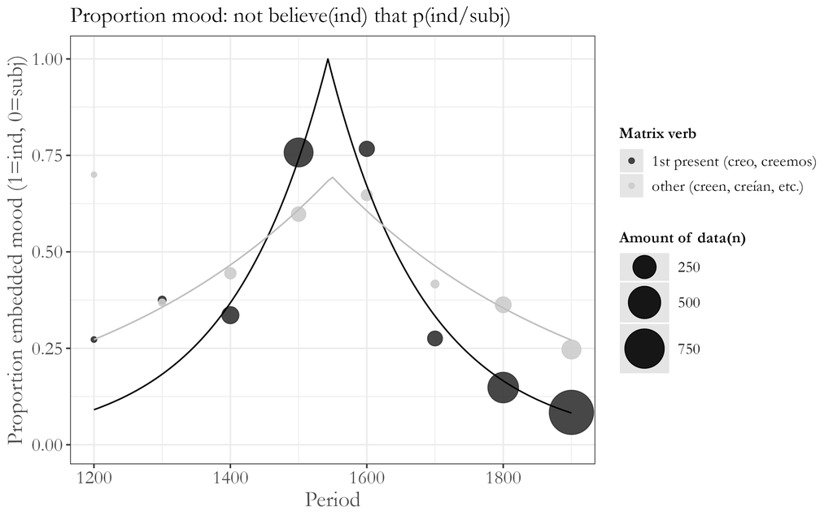

Mood Proportion after not believe that

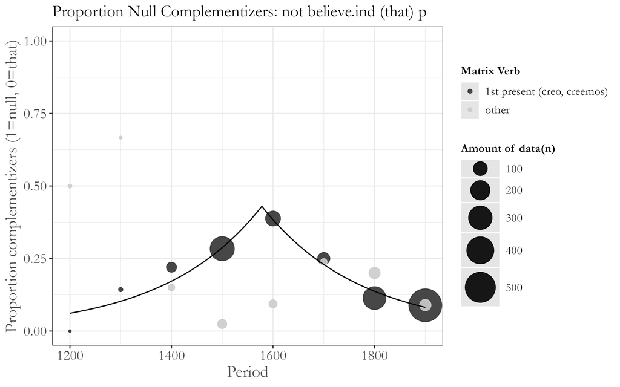

Change in Complementizer-drop only affected first person constructions

## 💡 Multiple Linguistic Changes

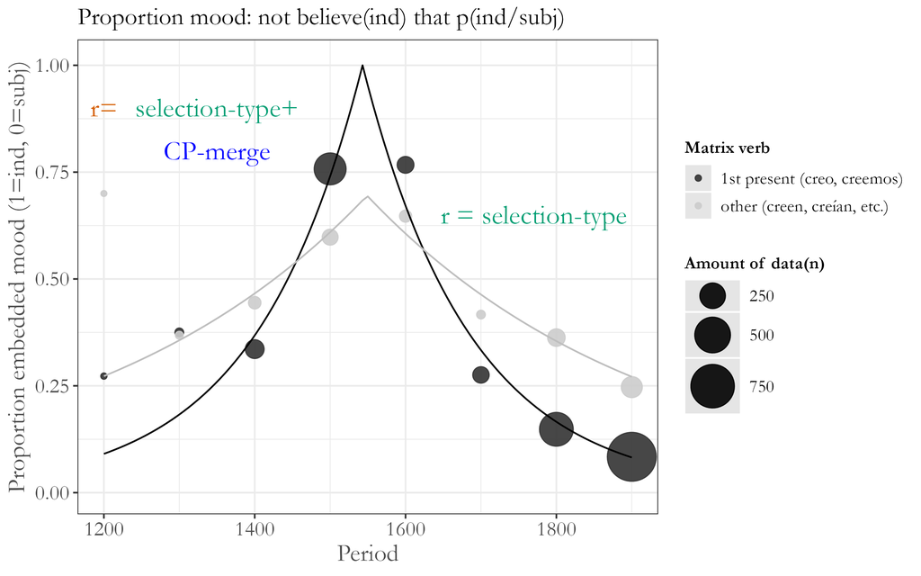

Mood Proportion after not believe that

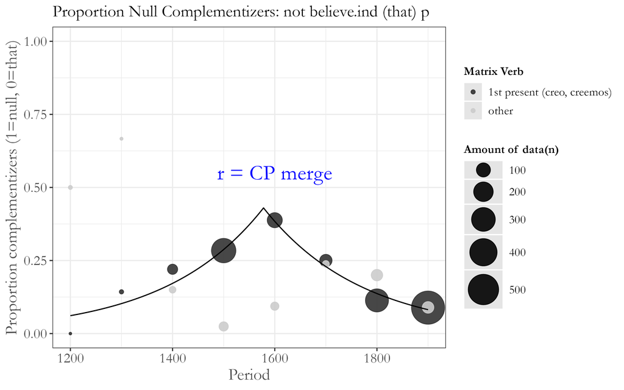

Complementizer-drop after not believe

Change in Complementizer-drop only affected 1st person constructions

## 🖥️ Rate of Change: First Approximation

- (Postma 2010) and (Bacovcin 2017): failed changes can be modeled as the combination of two logistics
- Simplified version: failed change is the combination of two exponentials (Laplace)

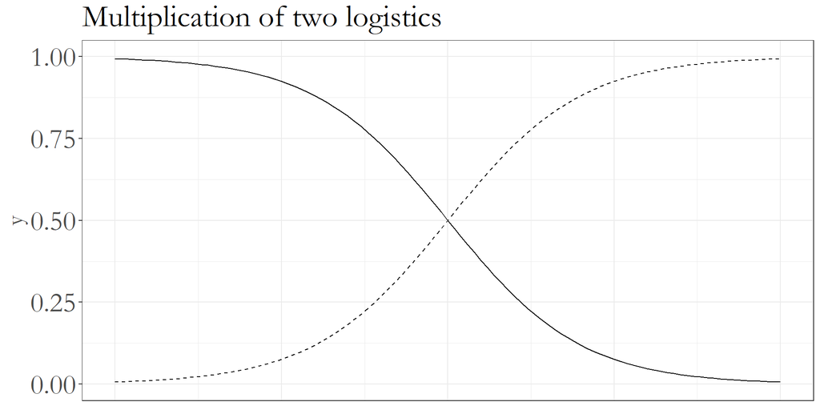

$$M(t)=\frac{1}{1+e^{-\frac{t-to}{s}}} \cdot \frac{1}{1+e^{-\frac{t-to'}{s'}}}$$

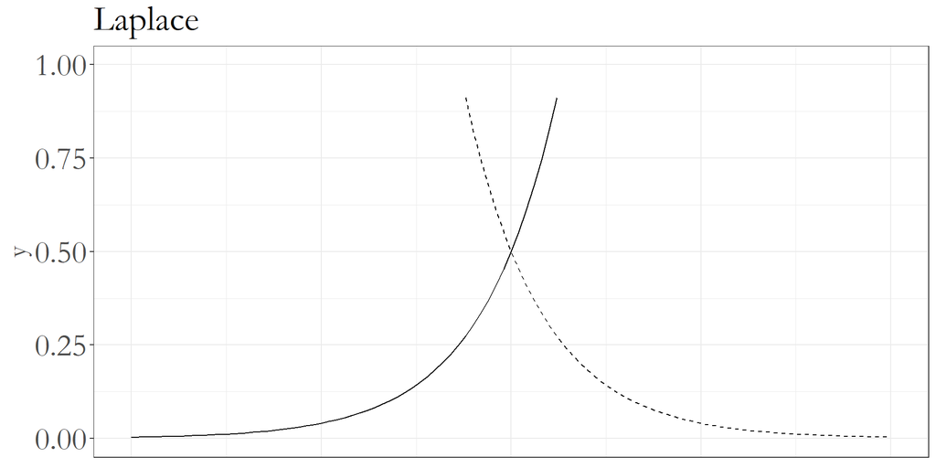

$$M(t)=q\cdot e^{-\frac{|t-to|}{s}}$$

where r= 1/s

## 🖥️ Model Fitting (nls)

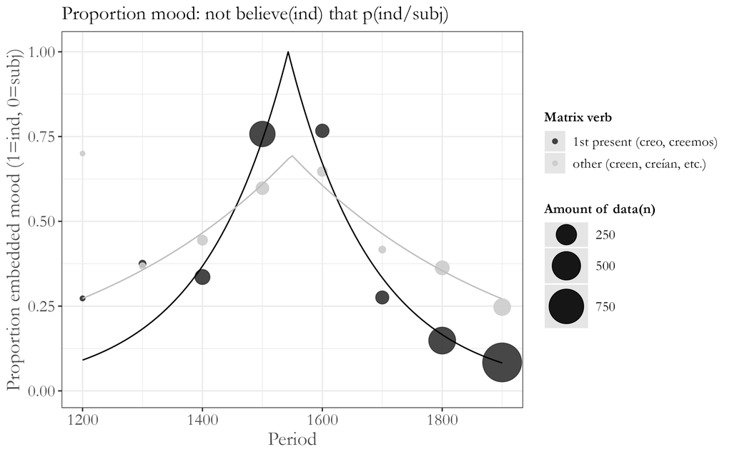

- First Person: $1\cdot e^{-\frac{|x-1543\pm8|}{143\pm14}}$
- Non-first Person: $0.695\cdot e^{-\frac{|x-1549\pm40|}{373\pm134}}$

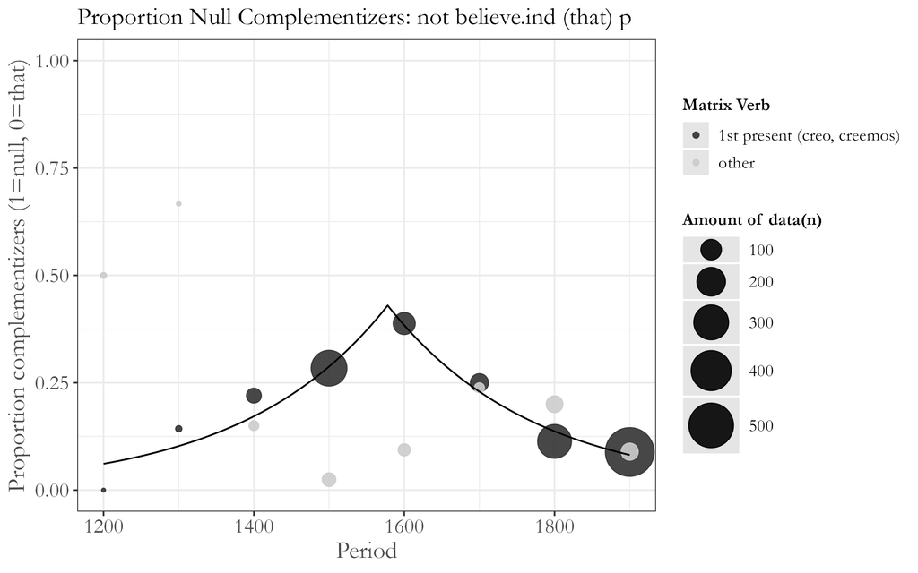

- First Person: $0.430\cdot e^{-\frac{|x-1578\pm18|)}{194\pm44}}$

## 🖥️ Adding the Effects:

- Result
- Mathematical Demonstration

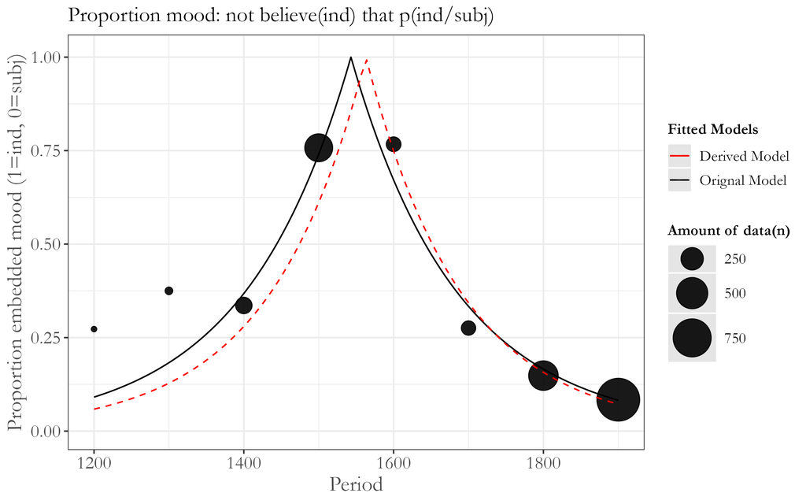

$\underbrace{q\cdot e^{-(\color{blue}{\overbrace{\frac{|t-to_c|}{s_c}}^{CP-merge}}+\color{green}{\overbrace{\frac{|t-to_b|}{s_b}}^{selection-type}})}}_{\color{red}{derived-model}}$ $\simeq \underbrace{q\cdot e^{\frac{|t-to_a|}{s_a}}}_{original -model}$

$q\cdot e^{-(\overbrace{\frac{|t-to_c|}{s_c}}^{CP-merge}+\overbrace{\frac{|t-to_b|}{s_b}}^{selection-type})}$

Making the assumption that $|t − to_c| ≈ |t - to_b|$, ( these values differ 30 years which given our scale can be considered a small difference), we obtain:

$q\cdot e^{-(\frac{1}{s_c}+\frac{1}{s_b})|t-to_{bc}|}$

where $to_{bc}$ is the mean between $to_b$ and $to_C$. By the general rules of rational functions we obtain:

$q\cdot e^{-(\frac{s_c + s_b}{s_c\cdot s_b})|t-to_{bc}|}$

Given that we have multiplied by n and our slope has the form 1/n, we need to dive by it again, leaving us with the following equation:

$q\cdot e^{-(\frac{s_c\cdot s_b}{s_c+s_b})|t-to_{bc}|}$

Then we just have to input our values: $s_c$=194, $s_b$=373, $to_{bc}=1563$

$q\cdot e^{-\frac{|t-1563|}{128}}$

As can be seen the obtained slope is very similar to the one obtained from fitting the original data: 128 $\simeq 143 \pm 14$

The value of q for plotting is the initial condition we are trying to model (in our case will be the one for First Person constructions which was equal to 1).

## Conclusion

1. **Is there a semantic difference in cases of mood alternation after negated non-factive verbs?**
   - Variational specialization: no.
2. **How can we formally characterize the alternation?**
- Competing Grammars: G1 is semantic selection, and G2 is case marking at the clausal level.
3. **What causes the First Person Effect with the verb *believe*?**
   - Constant Rate : first person constructions were affected by two linguistic changes; non-first person constructions were affected by a single change.

## Thank you for your attention!

Thanks to the team: George Walkden, Henri Kauhanen, Gemma McCarley, Molly Rolf and Sarah Einhaus. https://www.ling.uni-konstanz.de/en/walkden/starfish/

We gratefully acknowledge funding from the European Research Council, grant no. 851423 (STARFISH)

[figure not shown]

[figure not shown]

## References

Alonso, Emilio Ridruejo. 1999. “Modo y Modalidad. El Modo En Las Subordinadas Sustantivas.” In *Gramática Descriptiva de La Lengua Española*, 3209–52. Espasa Calpe.

Artiagoitia, Xabier, and Arantzazu Elordieta. 2016. “On the Semantic Function and Selection of Basque Finite Complementizers.” *Complementizer Semantics in European Languages*, 379–411.

Bacovcin, Hezekiah Akiva. 2017. “Modelling Interactions Between Morphosyntactic Changes.” *From Micro-Change to Macro-Change* 23: 94–103.

Baunaz, Lena, and Genoveva Puskás. 2022. *A Cross-Linguistic Approach to the Syntax of Subjunctive Mood*. Springer.

Błaszczak, Joanna. 2001. *Covert Movement and the Genitive of Negation in Polish*. Universitätsbibliothek Potsdam.

Borgonovo, Claudia. 2003. “MOOD AND FOCUS CLAUDIA BORGONOVO.” *Romance Languages and Linguistic Theory 2001: Selected Papers from’Going Romance,’Amsterdam, 6-8 December 2001* 245: 17.

Faulkner, Tris. 2021. *A Systematic Investigation of the Spanish Subjunctive: Mood Variation in Subjunctive Clauses*. Georgetown University.

Giannakidou, Anastasia. 2009. “The Dependency of the Subjunctive Revisited: Temporal Semantics and Polarity.” *Lingua* 119 (12): 1883–1908.

Giorgi, Alessandra, and Fabio Pianesi. 1997. *Tense and Aspect: From Semantics to Morphosyntax*. Oxford University Press on Demand.

Kagan, Olga. 2012. *Semantics of Genitive Objects in Russian: A Study of Genitive of Negation and Intensional Genitive Case*. Vol. 89. Springer Science & Business Media.

Kroch, Anthony S. 1989. “Reflexes of Grammar in Patterns of Language Change.” *Language Variation and Change* 1 (3): 199–244.

Montero, Raquel, and Maribel Romero. 2023. “Examining the Meaning of Polarity Subjunctive.”

Postma, Gertjan. 2010. “The Impact of Failed Changes.” *Continuity and Change in Grammar*, 269–302.

Quer, Josep. 1998. “Mood at the Interface.” PhD thesis, Universiteit Utrecht.

Reider, Michael. 1990. “Neg-Transportation, Neg-Trace, and the Choice of Mood in Spanish.” *Hispania* 73 (1): 212–22.

Ruhstaller, Stefan, and Marı́a Dolores Gordón Peral. 2017. “The Lexical Impact of Language Contact with Arabic on Spanish and Catalan.” *Lexicographica* 33 (2017): 277–96.

Schlenker, Philippe. 2003. “The Lazy Frenchman’s Approach to the Subjunctive.” *Romance Languages and Linguistic Theory* 2005: 269–309.

Torrego, E, and J Uriagereka. 1992. “Indicative Dependents, Ms.” *Inédito, University of Massachusetts and University of Maryland, Amherst MA and College Park, MD*.

Uriagereka, Juan. 1988. *On Government*. University of Connecticut.

Wallenberg, Joel C. 2019. “A Variational Theory of Specialization in Acquisition and Diachrony.” *The Determinants of Diachronic Stability* 254: 245.